# Loanbuilder EDA

Drey Upsher-Obear

November 15, 2018

## Setup & Data

These packages will be required for this EDA.

```r
library(devtools)
library(tidyverse)
library(RCurl)
library(statsr)
library(rmarkdown)
library(DataExplorer)
library(DescTools)
```

Now load the data from the .csv file.

```r
loans <- read.csv("loan.csv", header = TRUE, sep = ",")
```

Optional: load .csv from web directly.

```r
download <- getURL("https://www.kaggle.com/wendykan/lending-club-loan-data")

data <- read.csv(text = download)
```

Now we can start to clean and organize our data.

First, lets check our variables for this question (int_rate, funded_amnt) to see if it is a normal distribution.

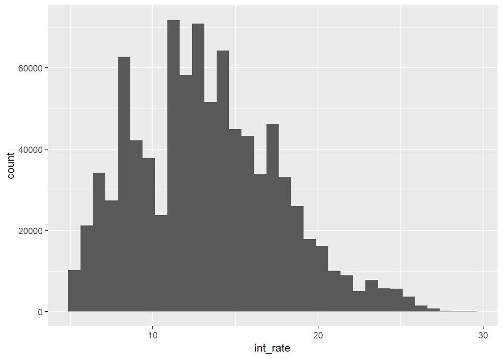

```r
loans %>%
  ggplot(aes(x = int_rate)) + geom_histogram(binwidth = .75)
```

Right off the bat, the interest rates seem to be fairly normal, with a notion of bimodal distribution with a right tail. It might be helpful to see some basic summary statistics for this data.

# Summary Statistics

```r
loans %>%
  summarise(m = mean(int_rate), med = median(int_rate),
            sigma = sd(int_rate), pop_iqr = IQR(int_rate),
            pop_max = max(int_rate), pop_min = min(int_rate),
            pop_q1 = quantile(int_rate, .25), # 25% percentile
            pop_q3 = quantile(int_rate, .75)) # 75% percentile
```

```
##          m   med    sigma pop_iqr pop_max pop_min pop_q1 pop_q3
## 1 13.24674 12.99 4.381867    6.21   28.99    5.32   9.99   16.2
```

Lets take some samples and see how they compare to the population. Our next step is to create a sampling distribution to find a point estimate. Creating a sample distribution also helps us determine variability when we are estimating the population mean.

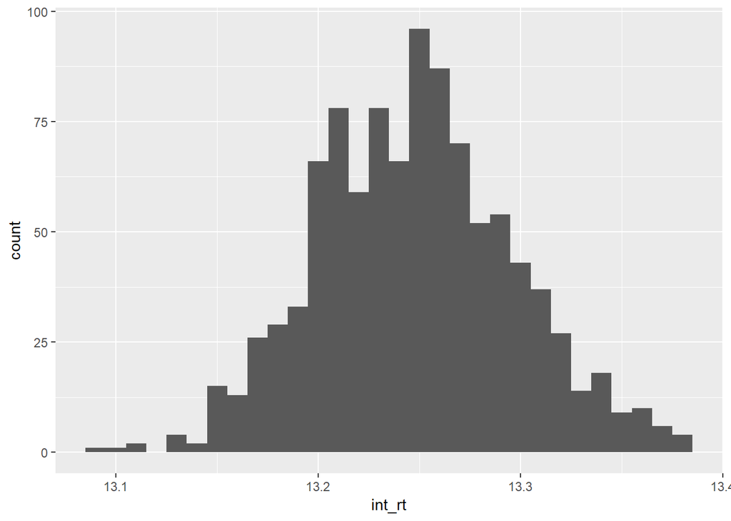

```r
sample_means.001 <- loans %>%
  rep_sample_n(size = 8000, reps = 1000, replace = TRUE) %>%
  summarise(int_rt = mean(int_rate), loan_amt = mean(loan_amnt), inst_amt = mean(installment))

ggplot(data = sample_means.001, aes(x = int_rt)) + geom_histogram(binwidth = .01)
```

This is looking good. The point estimate based on this sample distribution looks very close to the actual mean of interest rates. Based on the graph, I would estimate the mean (if I didnt already know) to be about 13.25 (pop avg: 13.246).

The reason we use the sampling distribution is because it is an unbiased, causing it to show the true mean. Ideally we should complete our point estimate inference by calculating the confidence level.

What I have gathered from this is the following;

1. While sample means only provide an estimate, the sizes of these samples are usually easier to work with than the population as a whole.
2. Point estimation of the mean becomes more accurate as the # of observations in the sample increases.

## Question 1

Can we associate the amount of the loan with its given grade? Can we deem this causation or correlation?

First lets clean and organize our data. Lets calculate the basic stats summary, and lets put in a 95% confidence interval for graphing purposes.

```r
amgr <- loans %>%
  group_by(grade) %>%
  summarise(m = mean(funded_amnt), s_d = sd(funded_amnt),
            ymax = max(funded_amnt), ymin = min(funded_amnt),
            y_IQR = IQR(funded_amnt), n.fund = n()) %>%
  mutate(se.fund = s_d / sqrt(n.fund),
         lower.ci = m - qt(1 - (.05 / 2), n.fund - 1) * se.fund,
         upper.ci = m + qt(1 - (.05 / 2), n.fund -1) * se.fund)
```

We will plot this with an error bar, in order to utilize the previous calculation of the confidence interval.

```
## geom_path: Each group consists of only one observation. Do you need to
## adjust the group aesthetic?
```

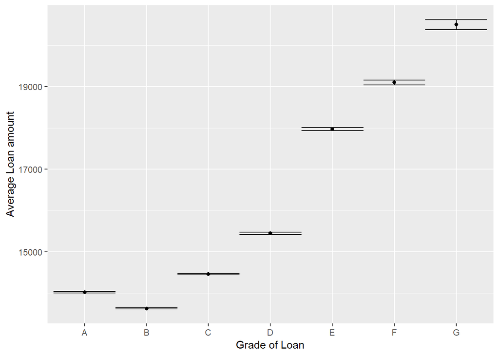

```r
amgr %>%
  ggplot(aes(x = grade, y = m)) + geom_errorbar(aes(ymin = m - se.fund, ymax = m + se.fund), width = 1) +
  geom_line() +
  geom_point()+
  xlab("Grade of Loan") +
  ylab("Average Loan amount")
```

An interesting observation arises; as the loan amount increases, the grade seems to diminish. In other words, the larger the loan, the worse the grade (or so it appears).

It it also interesting to note that the standard error increases as the grade decreases.

Now I will try the same process except this time I will be sampling, instead of drawing straight from the population. This should increase speed and decrease drag.

```r
amgr_v2 <- loans %>%
  rep_sample_n(size = 88737, reps = 10, replace = TRUE) %>%
  group_by(grade) %>%
  summarise(m = mean(funded_amnt), s_d = sd(funded_amnt), ymax = max(funded_amnt),
            ymin = min(funded_amnt), y_IQR = IQR(funded_amnt), n.fund = n()) %>%
  mutate(se.fund = s_d / sqrt(n.fund),
         lower.ci = m - qt(1 - (.05 / 2), n.fund - 1) * se.fund,
         upper.ci = m + qt(1 - (.05 / 2), n.fund -1) * se.fund)
```

Lets do the same graph and see if its similar.

```
## geom_path: Each group consists of only one observation. Do you need to
## adjust the group aesthetic?
```

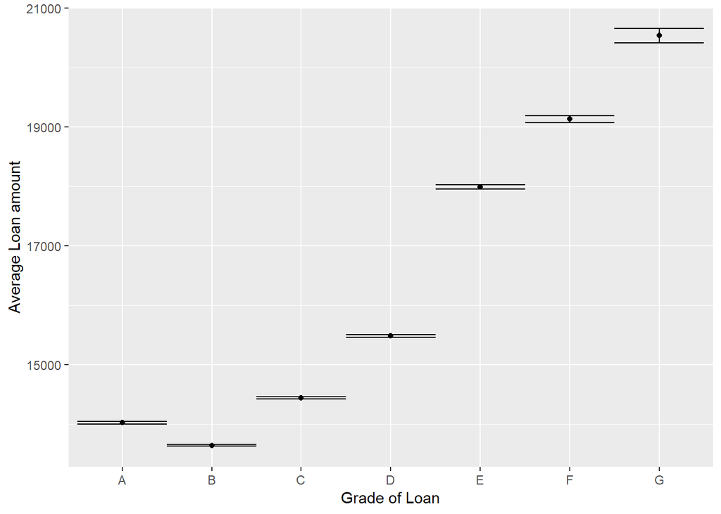

```r
amgr_v2 %>%
  ggplot(aes(x = grade, y = m)) + geom_errorbar(aes(ymin = m - se.fund, ymax = m + se.fund), width = 1) +
  geom_line() +
  geom_point()+
  xlab("Grade of Loan") +
  ylab("Average Loan amount")
```

Lets try to compare them. First we need to add a dummy variable to specify the group (population, sample). Combine both datasets into one “stepchild” data frame, in order to facet by group.

```r
amgr <- amgr %>%
  mutate(group = if_else(m > 0, "Population", "N/A"))

amgr_v2 <- amgr_v2 %>%
  mutate(group = if_else(m > 0, "Sample", "N/A"))

stepchild <- bind_rows(amgr, amgr_v2)
```

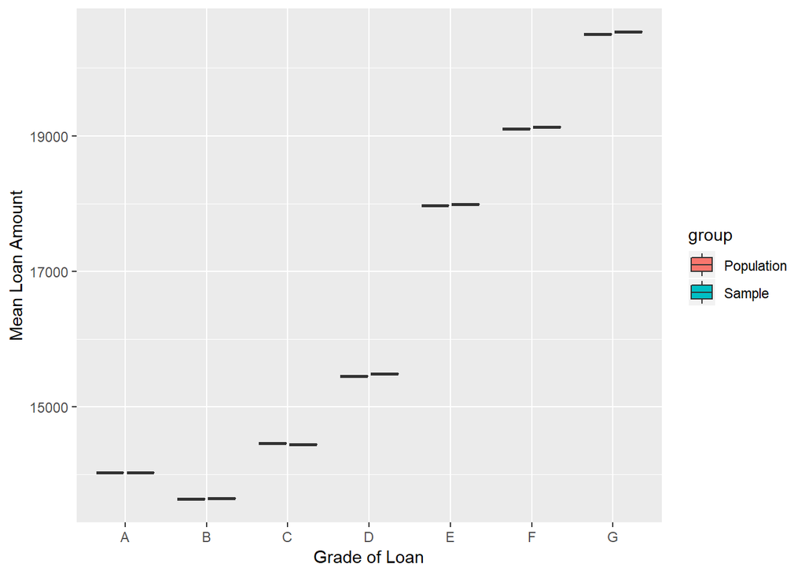

```r
stepchild %>%
  ggplot(aes(x = grade, y = m, fill = group)) +
  geom_boxplot() +
  ylab("Mean Loan Amount") +
  xlab("Grade of Loan")
```

# What does the distribution look like for the amount of the loan? This might be helpful in gathering an understanding of Lending Clubs portfolio.

```
## -------------------------------------------------------------------------
## Loan Amount Dist.
##
##     length         n       NAs    unique        0s      mean     meanCI
##      9e+05     9e+05         0     1e+03         0  1.48e+04   1.47e+04
##               100.0%      0.0%                0.0%             1.48e+04
##
##        .05       .10       .25    median       .75       .90        .95
##   3.60e+03  5.00e+03  8.00e+03  1.30e+04  2.00e+04  2.80e+04   3.20e+04
##
##      range        sd     vcoef       mad       IQR      skew       kurt
##   3.45e+04  8.44e+03  5.72e-01  8.60e+03  1.20e+04  6.82e-01  -2.57e-01
##
## lowest : 5.00e+02 (1e+01), 5.50e+02, 6.00e+02 (6e+00), 7.00e+02 (3e+00), 7.25e+02
## highest: 3.49e+04 (1e+01), 3.49e+04 (9e+00), 3.50e+04 (2e+01), 3.50e+04 (3e+01), 3.50e+04 (4e+04)
```

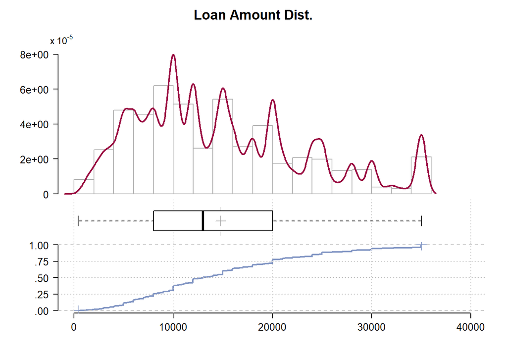

```r
  Desc(loans$loan_amnt, main = "Loan Amount Dist.", plotit = TRUE)
```

This shows a solid distribution among the portfolio. Because the distribution is focused around the ~ 10,000 dollar mark, it would be safe to assume that it would be more ideal to lose many small loans than a couple big ones. Depending on risk, this would inherently lower the overal volatility of the portfolio.

## Amount and status distribution

Regarding risk, we should also look at the amount distribution by status of the loan.

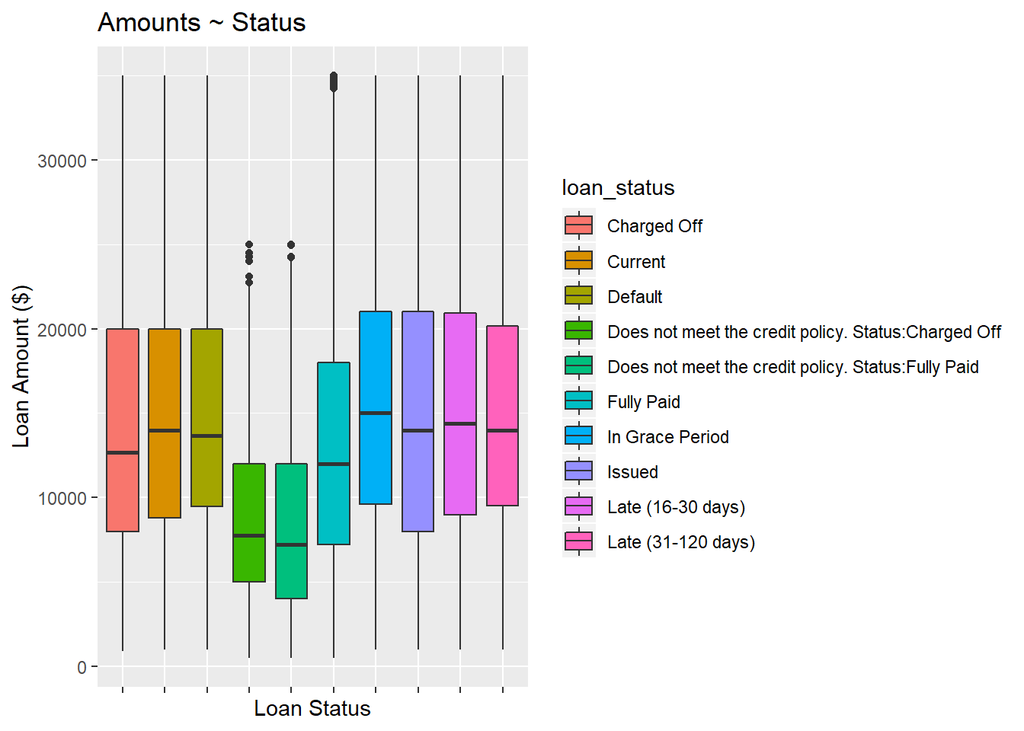

```r
loans %>%
  ggplot(aes(loan_status, loan_amnt)) +
  geom_boxplot(aes(fill = loan_status)) +
  theme(axis.text.x = element_blank()) +
  xlab("Loan Status") +
  ylab("Loan Amount ($)") +
  ggtitle("Amounts ~ Status")
```

This can be interprited as higher loan amounts generally have a ‘worse’ status, than those of lower amounts.

Lets see the same graph, but with interest rates instead of the loan amount.

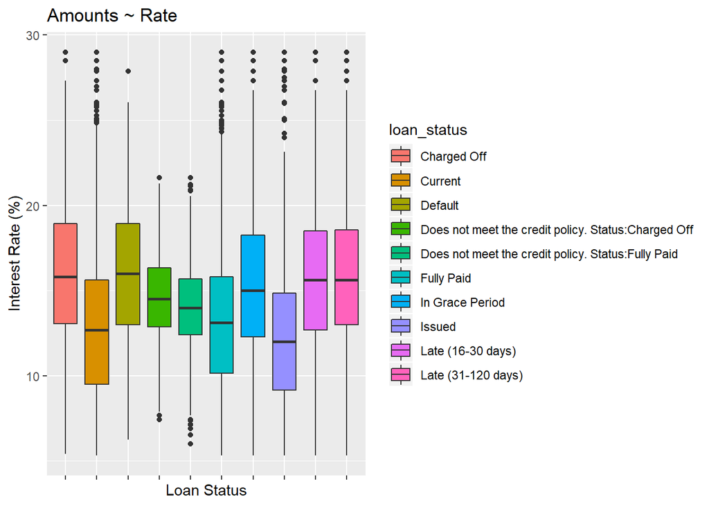

```r
loans %>%
  ggplot(aes(loan_status, int_rate)) +
  geom_boxplot(aes(fill = loan_status)) +
  theme(axis.text.x = element_blank()) +
  xlab("Loan Status") +
  ylab("Interest Rate (%)") +
  ggtitle("Amounts ~ Rate")
```

Interesting, almost a similar distribution to the amounts ~ status plot. I would assume this is due to the increased risk of the loan depending on the status, as well as the amount (IE, the other one).

## Suggested correlations

Here we can easily see possible correlations using the DataExplorer package, and the plot_correlation function. I only picked variables that I was specifically interested in during this EDA.

## Need to fix grade sub_cat.

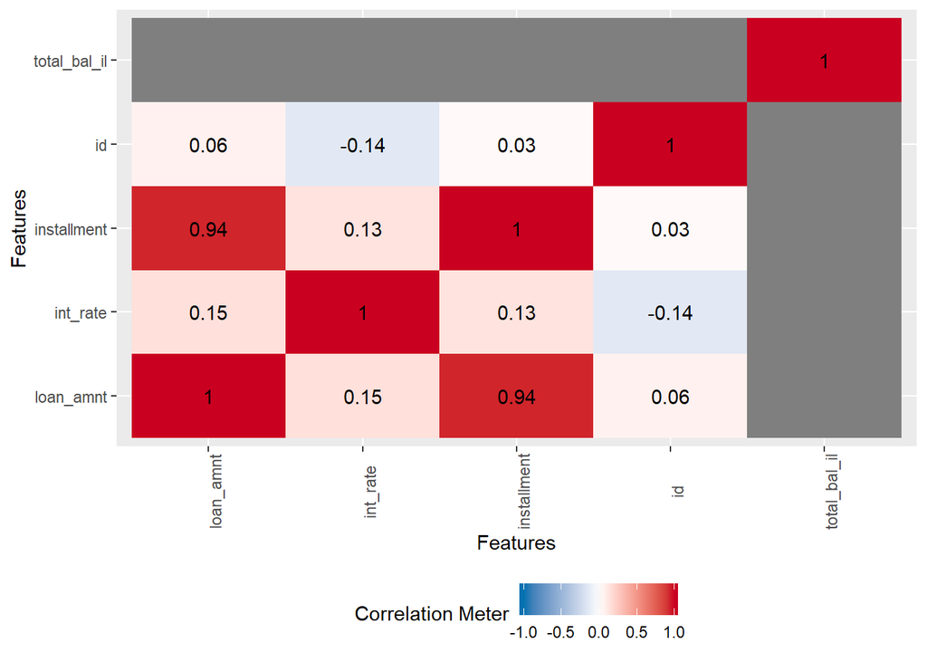

```r
clean <- loans %>%
  select(c(loan_amnt, int_rate, installment, as.factor(grade), total_bal_il))

plot_correlation(clean, maxcat = 10)
```

Lets see how their loan portfolio was growing over time. Just for fun.

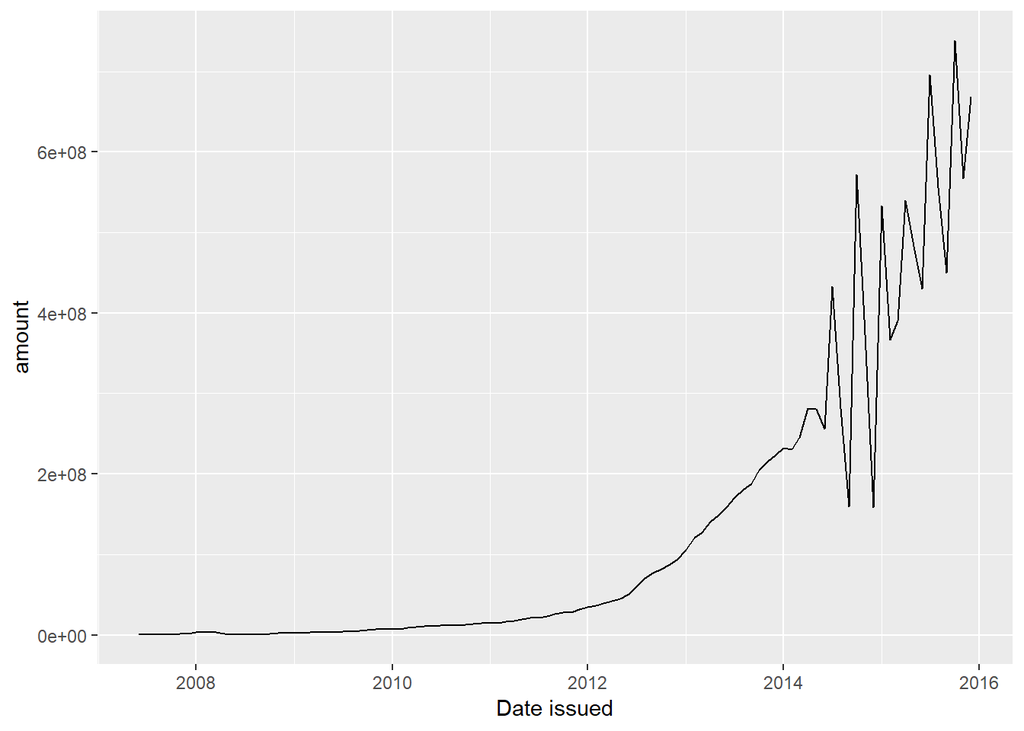

```r
loans$issue_d <- as.Date(gsub("^", "01-", loans$issue_d), format="%d-%b-%Y")

amnt_date <- loans %>%
  select(issue_d, loan_amnt) %>%
  group_by(issue_d) %>%
  summarise(amount = sum(loan_amnt))

amnt_date %>%
  ggplot(aes(x = issue_d, y = amount)) +
  geom_line() + xlab("Date issued")
```

Whats interesting is the amount of volatility which starts about a quarter way through 2014. Before then, the growth is rather smooth. Without any research, one could conclude this would be an effect of the growing popularity, but it also is observable they lost out on a couple big loans a few times.